# Stochastic Growth Exercises 3

Ferran Estrella Serra

2026-06-25

## Part I– Simulation of the Diffusion Process

```r
set.seed(123)
a0 <- 0.4
a1 <- 0.18
a2 <- -0.015
a3 <- 0.001
sigma <- 0.3

x0 <- 5
t0 <- 0
tf <- 25
time_seq <- seq(0, 25, length.out = 500)
dt <- diff(time_seq)[1]
```

1. Implement the cubic polynomial

```r
Q <- function(t) {
  a0+a1*t+a2*t^2+a3*t^3
}
```

2. Compute the theoretical expected trajectory:

```r
theoretical_mean <- x0 * (1+exp(-Q(t0))) / (1+exp(-Q(time_seq)))
```

3. Simulate M = 100 independent stochastic trajectories using the analytical solution

```r
M <- 100
N <- 500

set.seed(123)
paths0 <- matrix(0, nrow = N, ncol = M)
for(j in 1:M) {
  dW <- rnorm(N - 1, mean = 0, sd = sqrt(dt)) # N-1 random increments for each N-1 intervals
  W  <- c(0, cumsum(dW)) # Cumulative sums of increments for each time step
  paths0[, j] <- theoretical_mean * exp(-sigma^2/2*(time_seq-t0)+sigma*W)
}
```

Plot all trajectories in the same figure. Overlay the theoretical mean trajectory.

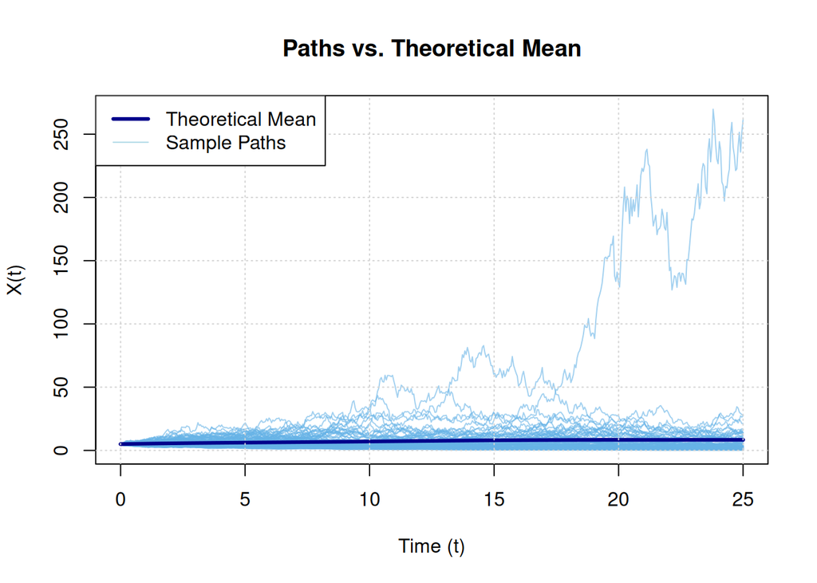

```r
plot(time_seq, theoretical_mean, type = 'l', col = 'darkblue', lwd = 3,
     ylim = c(0, max(paths0)), xlab = "Time (t)", ylab = "X(t)",
     main = "Paths vs. Theoretical Mean")
matlines(time_seq, paths0, type = 'l', lty = 1, col = rgb(0.4, 0.7, 0.9, 0.6))
lines(time_seq, theoretical_mean,
      col = "darkblue",
      lwd = 3)
grid()
legend("topleft", legend = c("Theoretical Mean", "Sample Paths"),
       col = c("darkblue", "lightblue"), lwd = c(3, 1))
```

Discuss how increasing σ affects the variability of the trajectories:

As we increase the volatility parameter σ, we increase the amplitude of the white noise added to the growth rate over time. This leads to an increase in the uncertainty of the process, since the stochastic paths are driven by noise with higher variance (X(t) follows a lognormal with higher variance). This is something we already explored in the previous task.

## Part II– Empirical First-Passage Time Estimation

Suppose that a critical biological threshold is defined as:

```r
S=8
```

1. For each simulated trajectory, compute the empirical first-passage time.
2. If a trajectory never crosses the threshold, mark the FPT as missing.

```r
empirical_FPT <- function(time_seq, path, S) {
  idx <- which(path >= S)[1]

  if (is.na(idx)) {
    return(NA)  # missing
  }
  return(time_seq[idx])
}

FPTs <- apply(paths0, 2, function(path) empirical_FPT(time_seq, path, S))
FPTs_obs <- na.omit(FPTs)
```

Of the total of M=100 paths, the number of paths crossing S in the considered range of time is:

```r
length(FPTs_obs)
```

```
## [1] 71
```

3. Estimate the empirical distribution of the crossing times. Create a histogram of the observed FPT values:

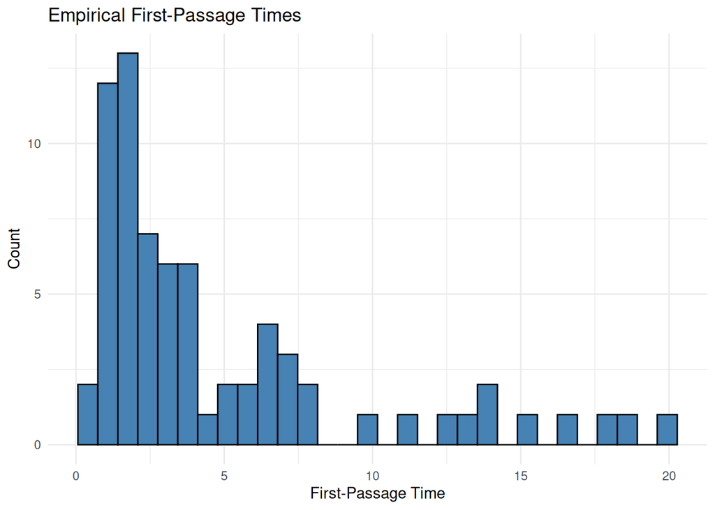

```r
ggplot(data.frame(FPT = FPTs_obs), aes(x = FPT)) +
  geom_histogram(bins = 30, color = "black", fill = "steelblue") +
  labs(
    title = "Empirical First-Passage Times",
    x = "First-Passage Time",
    y = "Count"
  ) +
  theme_minimal()
```

Compute the empirical mean, median and standard deviation:

```r
mean_FPT   <- mean(FPTs_obs)
median_FPT <- median(FPTs_obs)
sd_FPT     <- sd(FPTs_obs)
data.frame(
  Mean = mean(FPTs_obs),
  Median = median(FPTs_obs),
  SD = sd(FPTs_obs)
)
```

```
##       Mean   Median       SD
## 1 4.856191 2.905812 4.842744
```

Interpret:

- What is the expected time for the process to reach the threshold?

The empirical expected time for the process to reach the threshold, among the trajectories that do reach it within the considered range of time, is given by the mean first-passage time included in the previous table.

- Is the distribution symmetric or skewed?

## Part III– Numerical Approximation of the FPT Density

To approximate numerically the FPT density, we use the following library:

```r
#install.packages("fptdApprox")
library(fptdApprox)
```

1. Estimate the FPT density using the numerical Volterra equation solver.
2. Plot the theoretical numerical density.

```r
# 1. Define the mathematical components of the Pluri-Sigmoidal Diffusion Process
pluri_specs <- character(4)
pluri_specs[1] <- "(a1 + 2*a2*t + 3*a3*t^2) / (1 + exp(a0 + a1*t + a2*t^2 + a3*t^3)) * x"
pluri_specs[2] <- "sigma^2 * x^2"
pluri_specs[3] <- "dnorm((log(x) - (log(y) + log((1 + exp(-(a0 + a1*s + a2*s^2 + a3*s^3))) / (1 + exp(-(a0 + a1*t + a2*t^2 + a3*t^3)))) - (sigma^2/2)*(t-s))) / (sigma * sqrt(t-s))) / (sigma * sqrt(t-s) * x)"
pluri_specs[4] <- "plnorm(x, log(y) + log((1 + exp(-(a0 + a1*s + a2*s^2 + a3*s^3))) / (1 + exp(-(a0 + a1*t + a2*t^2 + a3*t^3)))) - (sigma^2/2)*(t-s), sigma * sqrt(t-s))"

Pluridifproc <-diffproc(pluri_specs)

# 2. Approximate the First-Passage Time Density
fpt_approximation <- Approx.fpt.density(
  dp = Pluridifproc,
  t0 = t0,
  T = tf,
  id = x0,
  S = S,
  env = list(a0 = a0, a1 = a1, a2 = a2, a3 = a3, sigma = sigma),
  to.T=TRUE
)
```

```
##
## Computing... Done.
##
## The value of the cumulative integral of the approximation is 0.706180724050745 < 1 - tol.
## It may be appropriate to extend the considered time interval.
```

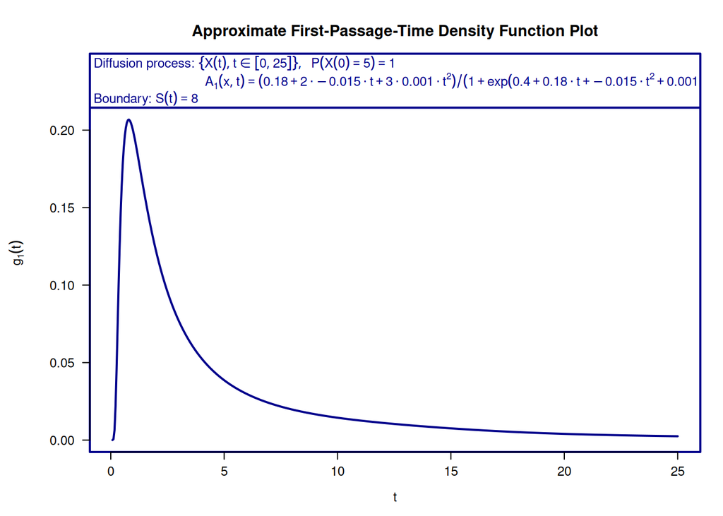

```r
# 3. Plotting the results
# The fptdApprox package has a native plot method for this object class,
# which generates a clean, precise visualization for your slides.
plot(fpt_approximation, main = "Pluri-sigmoidal FPT Density Approximation for σ = 0.3",
     col = "darkblue", lwd = 2)
```

3. Compare the numerical density with the empirical histogram obtained from simulations. Discuss: Do the two approaches provide similar results? Which approach is computationally more expensive?

The numerical method provides a smooth estimate of the density and is free from Monte Carlo sampling noise, while the empirical histogram relies on the simulated trajectories.

For a small number of paths (e.g. M=100), the histogram is computationally cheaper to obtain. However, to achieve a highly accurate empirical approximation, we would require a large number of trajectories, making the Monte Carlo approach significantly more expensive compared to the numerical method.

## Part IV– Effect of Volatility on the Peak Time

Repeat the analysis for other two different volatility levels: σ = 0.15 and σ = 0.60.

1. σ1 = 0.15

```r
M <- 200
N <- 500
sigma <- 0.15

set.seed(123)
paths <- matrix(0, nrow = N, ncol = M)
for(j in 1:M) {
  dW <- rnorm(N - 1, mean = 0, sd = sqrt(dt)) # N-1 random increments for each N-1 intervals
  W  <- c(0, cumsum(dW)) # Cumulative sums of increments for each time step
  paths[, j] <- theoretical_mean * exp(-sigma^2/2*(time_seq-t0)+sigma*W)
}

empirical_FPT <- function(time_seq, path, S) {
  idx <- which(path >= S)[1]

  if (is.na(idx)) {
    return(NA)  # missing
  }
  return(time_seq[idx])
}

FPTs <- apply(paths, 2, function(path) empirical_FPT(time_seq, path, S))
FPTs_obs <- na.omit(FPTs)

hist.15 <- ggplot(data.frame(FPT = FPTs_obs), aes(x = FPT)) +
  geom_histogram(bins = 30, color = "black", fill = "steelblue") +
  labs(
    title = "Empirical First-Passage Times",
    x = "First-Passage Time",
    y = "Count"
  ) +
  theme_minimal()

mean_FPT  <- mean(FPTs_obs)
median_FPT <- median(FPTs_obs)
sd_FPT <- sd(FPTs_obs)
CI_95 <- quantile(FPTs_obs, probs = c(0.025, 0.975))

new_df <- data.frame(
  σ = 0.15,
  proportion = length(FPTs_obs)/M,
  Mean = mean_FPT,
  Median = median_FPT,
  SD = sd_FPT,
  CI_lower = CI_95[1],
  CI_upper = CI_95[2]
)
df_stats <- new_df


pluri_specs <- character(4)
pluri_specs[1] <- "(a1 + 2*a2*t + 3*a3*t^2) / (1 + exp(a0 + a1*t + a2*t^2 + a3*t^3)) * x"
pluri_specs[2] <- "sigma^2 * x^2"
pluri_specs[3] <- "dnorm((log(x) - (log(y) + log((1 + exp(-(a0 + a1*s + a2*s^2 + a3*s^3))) / (1 + exp(-(a0 + a1*t + a2*t^2 + a3*t^3)))) - (sigma^2/2)*(t-s))) / (sigma * sqrt(t-s))) / (sigma * sqrt(t-s) * x)"
pluri_specs[4] <- "plnorm(x, log(y) + log((1 + exp(-(a0 + a1*s + a2*s^2 + a3*s^3))) / (1 + exp(-(a0 + a1*t + a2*t^2 + a3*t^3)))) - (sigma^2/2)*(t-s), sigma * sqrt(t-s))"

Pluridifproc <-diffproc(pluri_specs)

density.15 <- Approx.fpt.density(
  dp = Pluridifproc,
  t0 = t0,
  T = tf,
  id = x0,
  S = S,
  env = list(a0 = a0, a1 = a1, a2 = a2, a3 = a3, sigma = sigma),
  to.T=TRUE
)
```

```
##
## Computing... Done.
##
## The value of the cumulative integral of the approximation is 0.715458605211682 < 1 - tol.
## It may be appropriate to extend the considered time interval.
```

2. σ2 = 0.30

```r
M <- 200
N <- 500
sigma <- 0.30

set.seed(123)
paths <- matrix(0, nrow = N, ncol = M)
for(j in 1:M) {
  dW <- rnorm(N - 1, mean = 0, sd = sqrt(dt)) # N-1 random increments for each N-1 intervals
  W  <- c(0, cumsum(dW)) # Cumulative sums of increments for each time step
  paths[, j] <- theoretical_mean * exp(-sigma^2/2*(time_seq-t0)+sigma*W)
}

empirical_FPT <- function(time_seq, path, S) {
  idx <- which(path >= S)[1]

  if (is.na(idx)) {
    return(NA)  # missing
  }
  return(time_seq[idx])
}

FPTs <- apply(paths, 2, function(path) empirical_FPT(time_seq, path, S))
FPTs_obs <- na.omit(FPTs)

hist.30 <- ggplot(data.frame(FPT = FPTs_obs), aes(x = FPT)) +
  geom_histogram(bins = 30, color = "black", fill = "steelblue") +
  labs(
    title = "Empirical First-Passage Times",
    x = "First-Passage Time",
    y = "Count"
  ) +
  theme_minimal()

mean_FPT  <- mean(FPTs_obs)
median_FPT <- median(FPTs_obs)
sd_FPT <- sd(FPTs_obs)
CI_95 <- quantile(FPTs_obs, probs = c(0.025, 0.975))

new_df <- data.frame(
  σ = 0.30,
  proportion = length(FPTs_obs)/M,
  Mean = mean_FPT,
  Median = median_FPT,
  SD = sd_FPT,
  CI_lower = CI_95[1],
  CI_upper = CI_95[2]
)
df_stats <- rbind(df_stats, new_df)


pluri_specs <- character(4)
pluri_specs[1] <- "(a1 + 2*a2*t + 3*a3*t^2) / (1 + exp(a0 + a1*t + a2*t^2 + a3*t^3)) * x"
pluri_specs[2] <- "sigma^2 * x^2"
pluri_specs[3] <- "dnorm((log(x) - (log(y) + log((1 + exp(-(a0 + a1*s + a2*s^2 + a3*s^3))) / (1 + exp(-(a0 + a1*t + a2*t^2 + a3*t^3)))) - (sigma^2/2)*(t-s))) / (sigma * sqrt(t-s))) / (sigma * sqrt(t-s) * x)"
pluri_specs[4] <- "plnorm(x, log(y) + log((1 + exp(-(a0 + a1*s + a2*s^2 + a3*s^3))) / (1 + exp(-(a0 + a1*t + a2*t^2 + a3*t^3)))) - (sigma^2/2)*(t-s), sigma * sqrt(t-s))"

Pluridifproc <-diffproc(pluri_specs)

density.30 <- Approx.fpt.density(
  dp = Pluridifproc,
  t0 = t0,
  T = tf,
  id = x0,
  S = S,
  env = list(a0 = a0, a1 = a1, a2 = a2, a3 = a3, sigma = sigma),
  to.T=TRUE
)
```

```
##
## Computing... Done.
##
## The value of the cumulative integral of the approximation is 0.706180724050745 < 1 - tol.
## It may be appropriate to extend the considered time interval.
```

3. σ3 = 0.60

```r
M <- 200
N <- 500
sigma <- 0.60

set.seed(123)
paths <- matrix(0, nrow = N, ncol = M)
for(j in 1:M) {
  dW <- rnorm(N - 1, mean = 0, sd = sqrt(dt)) # N-1 random increments for each N-1 intervals
  W  <- c(0, cumsum(dW)) # Cumulative sums of increments for each time step
  paths[, j] <- theoretical_mean * exp(-sigma^2/2*(time_seq-t0)+sigma*W)
}

empirical_FPT <- function(time_seq, path, S) {
  idx <- which(path >= S)[1]

  if (is.na(idx)) {
    return(NA)  # missing
  }
  return(time_seq[idx])
}

FPTs <- apply(paths, 2, function(path) empirical_FPT(time_seq, path, S))
FPTs_obs <- na.omit(FPTs)

hist.60 <- ggplot(data.frame(FPT = FPTs_obs), aes(x = FPT)) +
  geom_histogram(bins = 30, color = "black", fill = "steelblue") +
  labs(
    title = "Empirical First-Passage Times",
    x = "First-Passage Time",
    y = "Count"
  ) +
  theme_minimal()

mean_FPT  <- mean(FPTs_obs)
median_FPT <- median(FPTs_obs)
sd_FPT <- sd(FPTs_obs)
CI_95 <- quantile(FPTs_obs, probs = c(0.025, 0.975))

new_df <- data.frame(
  σ = 0.60,
  proportion = length(FPTs_obs)/M,
  Mean = mean_FPT,
  Median = median_FPT,
  SD = sd_FPT,
  CI_lower = CI_95[1],
  CI_upper = CI_95[2]
)
df_stats <- rbind(df_stats, new_df)


pluri_specs <- character(4)
pluri_specs[1] <- "(a1 + 2*a2*t + 3*a3*t^2) / (1 + exp(a0 + a1*t + a2*t^2 + a3*t^3)) * x"
pluri_specs[2] <- "sigma^2 * x^2"
pluri_specs[3] <- "dnorm((log(x) - (log(y) + log((1 + exp(-(a0 + a1*s + a2*s^2 + a3*s^3))) / (1 + exp(-(a0 + a1*t + a2*t^2 + a3*t^3)))) - (sigma^2/2)*(t-s))) / (sigma * sqrt(t-s))) / (sigma * sqrt(t-s) * x)"
pluri_specs[4] <- "plnorm(x, log(y) + log((1 + exp(-(a0 + a1*s + a2*s^2 + a3*s^3))) / (1 + exp(-(a0 + a1*t + a2*t^2 + a3*t^3)))) - (sigma^2/2)*(t-s), sigma * sqrt(t-s))"

Pluridifproc <-diffproc(pluri_specs)

density.60 <- Approx.fpt.density(
  dp = Pluridifproc,
  t0 = t0,
  T = tf,
  id = x0,
  S = S,
  env = list(a0 = a0, a1 = a1, a2 = a2, a3 = a3, sigma = sigma),
  to.T=TRUE
)
```

```
##
## Computing... Done.
##
## The value of the cumulative integral of the approximation is 0.679621015910141 < 1 - tol.
## It may be appropriate to extend the considered time interval.
```

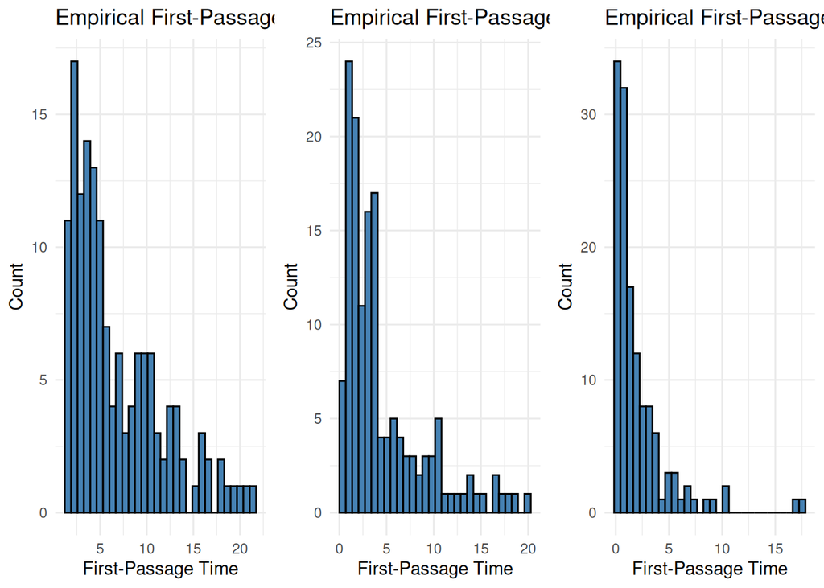

```r
grid.arrange(hist.15, hist.30, hist.60, ncol = 3)
```

```r
df_stats
```

```
##          σ proportion     Mean   Median       SD  CI_lower  CI_upper
## 2.5%  0.15       0.74 6.880653 5.160321 4.813010 1.6871242 18.727455
## 2.5%1 0.30       0.73 4.630151 3.081162 4.386265 0.5824148 16.802355
## 2.5%2 0.60       0.67 2.090749 1.077154 2.805767 0.1503006  9.828407
```

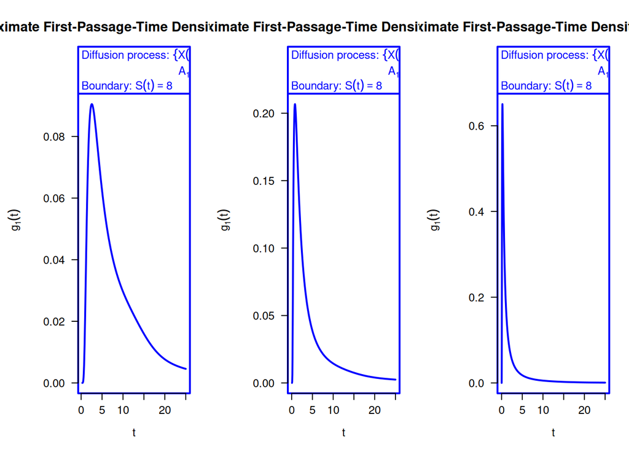

```r
par(mfrow = c(1, 3))

plot(density.15, main = "σ = 0.15", col = "blue", lwd = 2)
plot(density.30, main = "σ = 0.30", col = "blue", lwd = 2)
plot(density.60, main = "σ = 0.60", col = "blue", lwd = 2)
```

Questions:

1. Does increasing σ increase the uncertainty of the predicted crossing time? Explain the connection between volatility and skewness of the FPT distribution.

Not in this case. We observe that as we increase σ, the mean, median, standard deviation, and the bounds of the confidence interval decrease (as does the CI width). In addition, the peak of the density shifts to lower times and becomes (much) higher. This indicates that, as the volatility level increases, the crossing time tends to occur earlier with less dispersion.

Also, note that the proportion of simulated paths crossing the event decreases as σ increases, although only slightly.

2. Why can the median be more robust than the mean when σ is large?

When σ is large, the median can be more robust than the mean because, in a high volatility setting, there may be noisy trajectories that deviate substantially from the typical behaviour (underlying determinstic model) and cross the threshold much later than most paths. These late crossings increase the mean, while the median is less affected by such extreme values (robustness to outliers).

OBS: Note that the obtained results are not necessarily representative of the general asymptotic behaviour. We observe that since x0 and S are very close, as sigma increases, it increases the probability that stochastic fluctuations cause very early crossings of the threshold. This explains why the peak of the skewed density shifts towards lower times as σ increases, and why the density becomes more concentrated in this region.

Since we only observe a short time window, this early crossing effect induced by noise dominates the right-skewed behaviour that would emerge from delayed hitting times of more extreme trajectories. By increasing the time horizon and/or the distance between x0 and S, we would expect to observe the typical behaviour: increased variability in first-passage times and a right-skewed distribution effect due to delayed crossings of highly noisy paths.

## Part V– Early Prediction Scenario

1. Simulate the truncated dataset.

```r
# Prepares data for Scenario 1 (Full) and Scenario 2 (Truncated)
format_for_plot <- function(sim_output, truncate_at = NULL) {
  time_seq <- sim_output$Time
  trajectories <- sim_output$Trajectories

  # Convert matrix to long format dataframe
  df <- as.data.frame(trajectories)
  df$Time <- time_seq
  library(tidyr)
  df_long <- pivot_longer(df, cols = -Time, names_to = "Trajectory", values_to = "Value")

  # Calculate mean path
  df_mean <- df_long %>% group_by(Time) %>% summarise(Mean_Value = mean(Value))

  # Scenario 2: Truncate data if requested
  if (!is.null(truncate_at)) {
    df_long <- df_long %>% filter(Time <= truncate_at)
    df_mean <- df_mean %>% filter(Time <= truncate_at)
  }

  return(list(Paths = df_long, Mean = df_mean))
}
```

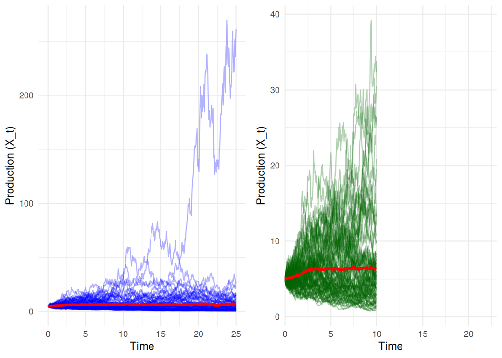

```r
sim_trajectories <- list(Time = time_seq, Trajectories = paths0)
# SCENARIO 1: Full Visualization
data_full <- format_for_plot(sim_trajectories)

plot_full <- ggplot(data_full$Paths, aes(x = Time, y = Value, group = Trajectory)) +
  geom_line(alpha = 0.3, color = "blue") +
  geom_line(data = data_full$Mean, aes(x = Time, y = Mean_Value, group = 1),
            color = "red", size = 1.2) +
  labs(
       y = "Production (X_t)", x = "Time") +
  theme_minimal()
# SCENARIO 2: Truncated Data (e.g., cutting off before the peak at year 1995)
data_trunc <- format_for_plot(sim_trajectories, truncate_at = 10)

plot_trunc <- ggplot(data_trunc$Paths, aes(x = Time, y = Value, group = Trajectory)) +
  geom_line(alpha = 0.3, color = "darkgreen") +
  geom_line(data = data_trunc$Mean, aes(x = Time, y = Mean_Value, group = 1),
            color = "red", size = 1.2) +
  labs(
       y = "Production (X_t)", x = "Time") +
  coord_cartesian(xlim = c(1, 22)) + # Keeps x-axis consistent with full plot
  theme_minimal()

# Display plots side-by-side using gridExtra (Requires gridExtra package)
grid.arrange(plot_full, plot_trunc, ncol = 2)
```

```r
T_obs <- 10

idx_obs <- which(time_seq <= T_obs)

time_trunc <- time_seq[idx_obs]
paths_trunc <- paths[idx_obs, ]
```

```r
empirical_FPT_trunc <- function(time_seq, path, S, T_obs) {
  idx <- which(path >= S & time_seq <= T_obs)[1]

  if (is.na(idx)) {
    return(NA)
  }

  return(time_seq[idx])
}
FPT_trunc <- apply(paths_trunc, 2, function(path) empirical_FPT_trunc(time_trunc, path, S, T_obs))
FPT_obs <- na.omit(FPT_trunc)
```

2. Use the FPT distribution to predict the future threshold-crossing time.

Expected crossing time:

```r
mean_FPT <- mean(FPT_obs)
```

```r
CI_95 <- quantile(FPT_obs, c(0.025, 0.975))
data.frame(
  Proportion = mean(!is.na(FPT_trunc)),
  Mean = mean_FPT,
  CI_lower = CI_95[1],
  CI_upper = CI_95[2]
)
```

```
##      Proportion     Mean  CI_lower CI_upper
## 2.5%       0.65 1.730769 0.1503006 6.901303
```

We observe that the proportion of paths crossing the event decreases, as expected. The mean and confidence interval bounds also decrease, since we are now only reporting crossings that occur within the earlier part of the observation window.

We can also use the numerically approximated density by setting as final time tf=10:

```r
pluri_specs <- character(4)
pluri_specs[1] <- "(a1 + 2*a2*t + 3*a3*t^2) / (1 + exp(a0 + a1*t + a2*t^2 + a3*t^3)) * x"
pluri_specs[2] <- "sigma^2 * x^2"
pluri_specs[3] <- "dnorm((log(x) - (log(y) + log((1 + exp(-(a0 + a1*s + a2*s^2 + a3*s^3))) / (1 + exp(-(a0 + a1*t + a2*t^2 + a3*t^3)))) - (sigma^2/2)*(t-s))) / (sigma * sqrt(t-s))) / (sigma * sqrt(t-s) * x)"
pluri_specs[4] <- "plnorm(x, log(y) + log((1 + exp(-(a0 + a1*s + a2*s^2 + a3*s^3))) / (1 + exp(-(a0 + a1*t + a2*t^2 + a3*t^3)))) - (sigma^2/2)*(t-s), sigma * sqrt(t-s))"

Pluridifproc <-diffproc(pluri_specs)

fpt_approximation <- Approx.fpt.density(
  dp = Pluridifproc,
  t0 = t0,
  T = 10, #truncation
  id = x0,
  S = S,
  env = list(a0 = a0, a1 = a1, a2 = a2, a3 = a3, sigma = sigma),
  to.T=TRUE
)
```

```
##
## Computing... Done.
##
## The value of the cumulative integral of the approximation is 0.648218536049121 < 1 - tol.
## It may be appropriate to extend the considered time interval.
```

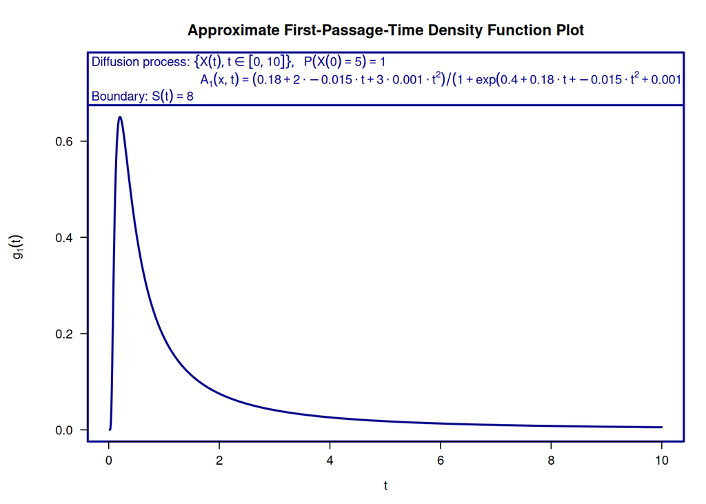

```r
plot(fpt_approximation, main = "Pluri-sigmoidal FPT Density Approximation for σ = 0.3",
     col = "darkblue", lwd = 2)
```

```r
t_grid <- fpt_approximation$x
f_grid <- fpt_approximation$y

dt <- diff(t_grid)[1]
f_grid <- f_grid / sum(f_grid * dt) # normalization

EX <- sum(t_grid * f_grid) * dt
EX2 <- sum((t_grid^2) * f_grid) * dt
SD_FPT <- sqrt(EX2 - EX^2)

cdf <- cumsum(f_grid) * dt # for quantiles
cdf <- pmin(pmax(cdf, 0), 1)
CI_95 <- c(
  t_grid[which(cdf >= 0.025)[1]],
  t_grid[which(cdf >= 0.975)[1]]
)

results_FPT <- data.frame(
  Mean = EX,
  SD = SD_FPT,
  CI_lower = CI_95[1],
  CI_upper = CI_95[2]
)
results_FPT
```

```
##       Mean       SD  CI_lower CI_upper
## 1 1.575101 1.919474 0.1122448 7.611339
```

This yields a more accurate prediction of the expected FPT.